# Where Do Shelter Dogs Come From?

Amber Thomas

Last updated: July 10, 2019

## Introduction

A few weeks ago, I was walking with a friend and discussing how hard it is to adopt a dog in Seattle. The thing is, Seattle is such a dog-friendly area, that rescue dogs go incredibly quickly. So much so that many rescues actually *import* dogs in need of homes from other states and sometimes other countries.

Data collection process can be found in `data_collection.Rmd` whereas analysis can be found in this file.

### Load Packages

```r
# For general data cleaning and analysis
library(tidyverse)

# For keeping your files in relative directories
library(here)

# If your data includes dates that need to be wrangled
library(lubridate)

# For interactive/searchable tables in your report
library(DT)
```

### Load Data

There are 3 data files that I will load in here:

- **dogs**: from data collected from the PetFinder API
- **descriptions**: Scraped descriptions from each animal’s profile
- **allFrom**: The states and countries that 3,361 of the animal’s had listed in their profile as their point of origin.

```r
dogsTrim <- read_csv(here::here("assets", "data", "processed_data", "dogsTrim.csv")) %>%
  mutate(id = as.character(id))

descriptions <- read_csv(here::here("assets", "data", "raw_data", "all_descriptions.csv"))

allFrom <- read_csv(here::here("assets", "data", "processed_data", "allFrom.csv"))
```

## Exploration

Alright, now to explore the data that we’ve imported.

### How many dogs total came from out of state?

```r
removeID <- c("08057", "19053", "33578", "85016", "QC")
`%notin%` <- purrr::negate(`%in%`)

outOfState <- dogsTrim %>%
  left_join(allFrom) %>%
  filter(!is.na(cleanLoc)) %>%
  mutate(contact_state_full = ifelse(is.na(state.name[match(contact_state, state.abb)]), contact_state, state.name[match(contact_state, state.abb)]) ,
    same = ifelse(contact_state_full == cleanLoc, TRUE, FALSE)) %>%
  filter(same == FALSE) %>%
  filter(contact_state_full %notin% removeID)
```

Ok, so 2227 dogs (4.1874283%) of dogs with written descriptions, have come from out of state.

### Most common passages

Let’s look at where dogs most commonly go from -> to.

```r
fromTo <- outOfState %>%
  group_by(cleanLoc, contact_state_full) %>%
  count(., sort = TRUE) %>%
  rename(from = cleanLoc, to = contact_state_full)
```

| from | to | n |
| --- | --- | --- |
| Texas | New York | 170 |
| Texas | Washington | 121 |
| Texas | New Jersey | 105 |
| California | Washington | 104 |
| Alabama | Pennsylvania | 99 |
| Alabama | Maryland | 75 |
| North Carolina | New Jersey | 67 |
| Texas | Maine | 58 |
| South Korea | Washington | 50 |
| Texas | Colorado | 48 |

[output cut: 342 more lines]

Alright so Texas to New York is the most common route.

### Most Exported

Which state or country exports the most dogs?

```r
most_exported <- outOfState %>%
  group_by(cleanLoc) %>%
  count(., sort = TRUE)
```

| cleanLoc | n |
| --- | --- |
| Texas | 661 |
| Alabama | 283 |
| North Carolina | 196 |
| California | 121 |
| Georgia | 101 |
| Louisiana | 94 |
| South Carolina | 81 |
| South Korea | 77 |
| Kentucky | 57 |
| West Virginia | 50 |

[output cut: 63 more lines]

### Most Imported

Which state imports the most dogs?

```r
most_imported <- outOfState %>%
  group_by(contact_state_full) %>%
  count(., sort = TRUE)
```

| contact_state_full | n |
| --- | --- |
| New York | 372 |
| Washington | 318 |
| New Jersey | 290 |
| Pennsylvania | 195 |
| Virginia | 149 |
| Maryland | 124 |
| Maine | 103 |
| Massachusetts | 65 |
| Colorado | 64 |
| Rhode Island | 56 |

[output cut: 27 more lines]

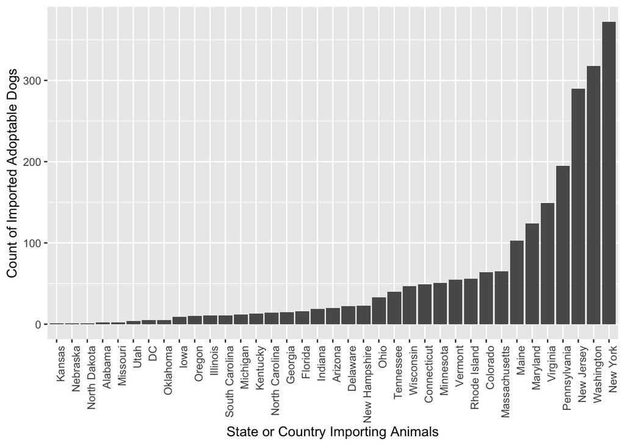

### Percentage of Imports per State

Out of animals that have listed an origin location, how many were moved from out of state?

```r
perState <- dogsTrim %>%
  left_join(allFrom) %>%
  filter(!is.na(cleanLoc)) %>%
  mutate(contact_state_full = ifelse(is.na(state.name[match(contact_state, state.abb)]), contact_state, state.name[match(contact_state, state.abb)]) ,
    same = ifelse(contact_state_full == cleanLoc, TRUE, FALSE)) %>%
  group_by(contact_state_full) %>%
  count(., same = TRUE)

percentImports <- perState %>%
  rename(countPerState = n) %>%
  left_join(most_imported) %>%
  rename(countImported = n) %>%
  filter(!is.na(countImported)) %>%
  mutate(percentImported = round((countImported/countPerState) * 100))
```

So a few states have imported 100% of their animals that list acquisition location.

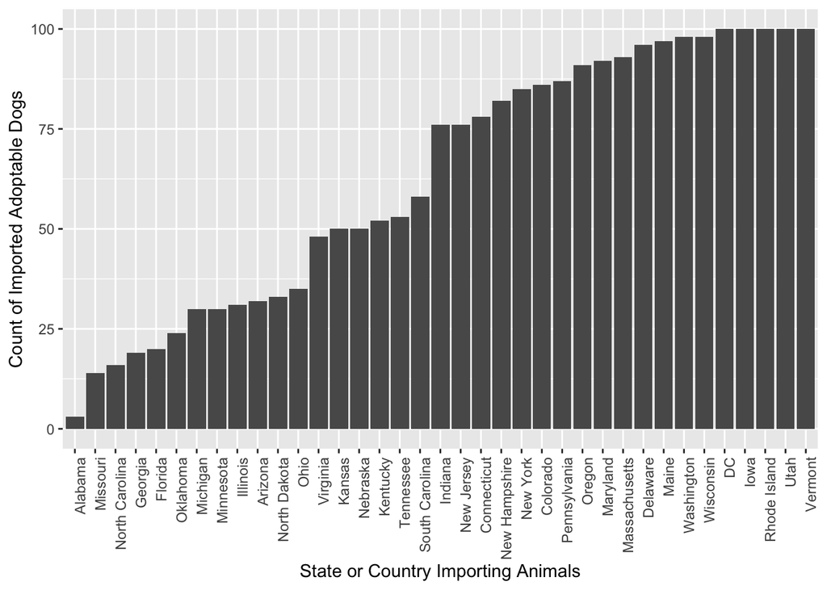

### Percent of Imports per State out of all Listings

Above I looked at the percentage of dogs imported out of animals that had an acquisition location listed. But, we can also assume that any animal without that information was acquired in-state. What percentage of total animals have a listed acquisition location out of state?

```r
perStateAll <- dogsTrim %>%
  # keep only dogs that had descriptions
  filter(id %in% descriptions$id) %>%
  mutate(contact_state_full = ifelse(is.na(state.name[match(contact_state, state.abb)]), contact_state, state.name[match(contact_state, state.abb)])) %>%
  count(contact_state_full, sort = TRUE) %>%
  filter(!grepl("[[:digit:]]", contact_state_full))

percentImportsAll <- perStateAll %>%
  rename(countPerState = n) %>%
  left_join(most_imported) %>%
  rename(countImported = n) %>%
  filter(!is.na(countImported)) %>%
  mutate(percentImported = round((countImported/countPerState) * 100))
```

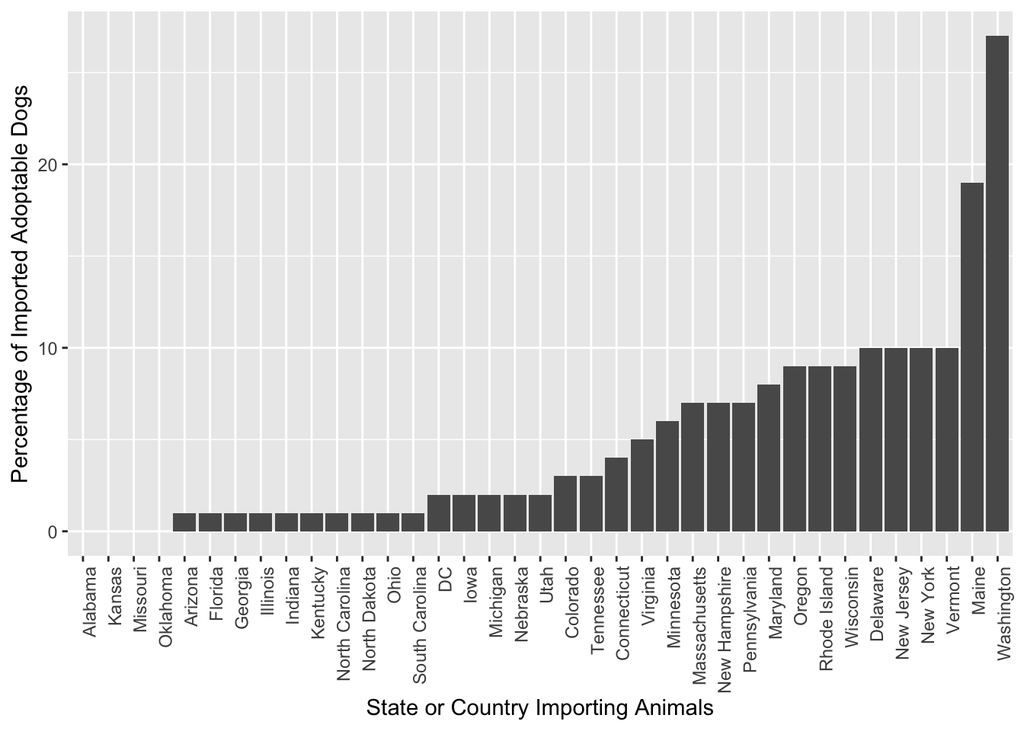

Alright, so it seems like my gut feeling was spot-on, Washington state is importing the highest percentage of dogs from out of state.

### Available for Adoption vs. Exports

While running the above calculations, I stumbled upon something seemingly interested. In the state of Texas, there are 418 animals available for adoption. But, Texas has *exported* 661 animals to other states for adoption. That is, they are supplying more animals to other parts of the country than to their own. Are any other states doing this?

```r
adoptionVExport <- perStateAll %>%
  rename(availablePerState = n) %>%
  left_join(most_exported, by = c("contact_state_full" = "cleanLoc")) %>%
  rename(exportedPerState = n) %>%
  mutate(diff = availablePerState - exportedPerState) %>%
  arrange(diff)

head(adoptionVExport)
```

| contact_state_full | availablePerState | exportedPerState | diff |
| --- | --- | --- | --- |
| Texas | 418 | 661 | -243 |
| Hawaii | 5 | 6 | -1 |
| South Dakota | 14 | 1 | 13 |
| Idaho | 46 | 1 | 45 |
| Oregon | 109 | 3 | 106 |
| Delaware | 212 | 1 | 211 |

Looks, like Texas and Hawaii are the only states sending more animals out of state than it retains in the state. Though, Hawaii only exported one more animal than it made available, Texas exported 243 more dogs than are available for adoption (with descriptions).